# Estadística Inferencial — Semana 5

Prueba de Hipótesis para la Media | Logística y Distribución Industrial

Prof. Fausto Noé Jiménez | SABES Campus San Felipe

Del 9 al 16 de junio de 2026

**Universidad del SABES — Campus San Felipe**

Estadística Inferencial | Semana 5 | Módulo III | Mayo–Agosto 2026

Prof. Fausto Noé Jiménez

# Tu Actividad de esta Semana

### Actividad 5 — Prueba de Hipótesis para la Media

**Valor:** 10 puntos | **Fecha límite:** 16 de junio | **Entrega:** Plataforma educativa en PDF

**Instrucciones:**

**Parte I — Responde estas 3 preguntas teóricas** (3 pts):

1. ¿Qué es una prueba de hipótesis?
2. ¿Cuáles son los pasos para realizar una prueba de hipótesis?
3. ¿Cuáles son los tipos de error en una prueba de hipótesis? Ilustra con un ejemplo de logística.

**Parte II — Resuelve los 3 ejercicios de logística industrial** (7 pts):

1. **CEDIS Irapuato** — Prueba de una media, cola derecha, α=5%
2. **Planta León** — Prueba de una media, dos colas, α=10%
3. **Rutas de distribución** — Prueba de dos medias independientes, cola derecha, α=1%

**Herramienta:** Resuelve en R (Posit.cloud) o Python (Positron). Incluye capturas de pantalla como evidencia.

# Marco Teórico

## 3.1 Elementos de una Prueba de Hipótesis

Una **prueba de hipótesis** es un procedimiento estadístico que permite tomar decisiones sobre los parámetros de una población a partir de los datos de una muestra.

Elementos de una prueba de hipótesis

| Elemento | Descripción |
| --- | --- |
| H0 (Hipótesis nula) | Afirmación que se somete a prueba. Siempre contiene =, <= o >= |
| H1 (Hipótesis alternativa) | Lo que queremos demostrar. Contiene !=, > o < |
| Nivel de significancia (alpha) | Probabilidad de cometer Error Tipo I. Común: 0.01, 0.05, 0.10 |
| Estadístico de prueba | Valor calculado con los datos muestrales (Z o t) |
| Valor crítico | Umbral que delimita región de rechazo según alpha |
| Región de rechazo | Valores del estadístico que llevan a rechazar H0 |
| p-value | Probabilidad de obtener un resultado tan extremo o más bajo H0 |
| Conclusión | Si p-value <= alpha -> rechazar H0. Si p-value > alpha -> no rechazar H0 |

## 3.2 Tipos de Error

**Error Tipo I (α):** Rechazar H₀ cuando es verdadera. “Falsa alarma”. Su probabilidad es el nivel de significancia α.  
**Error Tipo II (β):** No rechazar H₀ cuando es falsa. “Pasar por alto un problema real”. Su probabilidad es β.

Tabla de decisiones y tipos de error

| Realidad / Decision | Rechazar H0 | No rechazar H0 |
| --- | --- | --- |
| H0 es VERDADERA | Error Tipo I (alfa) - FALSA ALARMA | Decision CORRECTA (confianza = 1-alfa) |
| H0 es FALSA | Decision CORRECTA (Potencia = 1-beta) | Error Tipo II (beta) - OMISION |

**Ejemplo en logística:** Una planta establece que el tiempo promedio de carga de un camión es ≤ 30 min.

- **Error Tipo I:** Concluir que los camiones tardan más de 30 min cuando en realidad no es así → se incurre en costos innecesarios de mejora.
- **Error Tipo II:** No detectar que los camiones sí tardan más de 30 min → se pierde productividad sin intervenir.

## 3.3 Pasos de una Prueba de Hipótesis

Pasos de una prueba de hipótesis para la media

| Paso | Acción | Detalle |
| --- | --- | --- |
| 1 | Plantear H0 y H1 | H0 siempre tiene = &#124; H1 define el tipo de prueba (cola derecha, izquierda o dos colas) |
| 2 | Fijar el nivel de significancia alpha | Nivel de riesgo aceptable de cometer Error Tipo I (0.01, 0.05 o 0.10) |
| 3 | Elegir el estadístico de prueba (Z si n>=30, t si n<30) | n>=30: Z = (x̄ - mu0)/(s/√n) &#124; n<30 y σ desconocida: t con n-1 grados de libertad |
| 4 | Calcular el estadístico con los datos muestrales | Sustituir valores: n, x̄, s, mu0 |
| 5 | Determinar el valor crítico y la región de rechazo | Cola derecha: Z > Zalpha &#124; Cola izquierda: Z < -Zalpha &#124; Dos colas: &#124;Z&#124; > Zalpha/2 |
| 6 | Comparar y concluir (rechazar o no rechazar H0) | p-value <= alpha -> Rechazar H0 (hay evidencia suficiente) |

## Fórmulas principales

**Estadístico Z para una media (n ≥ 30):**

$$Z = \frac{\bar{x} -
\mu_0}{\dfrac{s}{\sqrt{n}}}$$

**Estadístico Z para diferencia de dos medias independientes (n₁, n₂ ≥ 30):**

$$Z = \frac{(\bar{x}_1 - \bar{x}_2) -
\Delta_0}{\sqrt{\dfrac{s_1^2}{n_1} + \dfrac{s_2^2}{n_2}}}$$

**Valores críticos comunes:**

Valores críticos Z más utilizados

| alpha | Cola_derecha | Cola_izquierda | Dos_colas |
| --- | --- | --- | --- |
| 0.10 | Z > 1.282 | Z < -1.282 | &#124;Z&#124; > 1.645 |
| 0.05 | Z > 1.645 | Z < -1.645 | &#124;Z&#124; > 1.960 |
| 0.01 | Z > 2.326 | Z < -2.326 | &#124;Z&#124; > 2.576 |

# Ejemplo Resuelto (Para practicar en Posit.cloud / Positron)

> Antes de resolver tu actividad, estudia este ejemplo completo. Luego corre el código en R y Python con tus propios datos.

## Contexto: CEDIS Monterrey — tiempo de entrega

El gerente de un CEDIS en Monterrey afirma que el tiempo promedio de entrega de pedidos es de **50 minutos**. Un auditor toma una muestra de **n = 36** pedidos y obtiene una **media muestral de 53.4 min** con **desviación estándar de 9 min**. Con α = 5%, ¿hay evidencia de que el tiempo real de entrega **excede** los 50 minutos?

## Solución paso a paso

**Paso 1 — Hipótesis:**

$$H_0: \mu = 50 \text{ min} \qquad H_1:
\mu > 50 \text{ min (cola derecha)}$$

**Paso 2 — Nivel de significancia:** α = 0.05

**Paso 3 — Estadístico:** n = 36 ≥ 30 → usar Z

$$Z = \frac{53.4 - 50}{9/\sqrt{36}} =
\frac{3.4}{1.5} = 2.267$$

**Paso 4 — Valor crítico:** Z₀.₀₅ = 1.645 (cola derecha)

**Paso 5 — Regla de decisión:** Rechazar H₀ si Z > 1.645

**Paso 6 — Conclusión:** Z_calc = 2.267 > 1.645 → **Rechazar H₀**. Hay evidencia estadística suficiente al 5% para afirmar que el tiempo promedio de entrega excede los 50 minutos.

## Código en R — Posit.cloud

**Instrucciones Posit.cloud:** File → New File → R Script → pega el código → Ctrl+A → Ctrl+Enter

```r
# ============================================================
# PRUEBA DE HIPÓTESIS PARA LA MEDIA -- R BASE PURO
# EJEMPLO: CEDIS Monterrey -- tiempo de entrega
# Posit.cloud: File -> New R Script -> Ctrl+A -> Ctrl+Enter
# ============================================================

# --- DATOS DEL PROBLEMA ---
n     <- 36      # tamaño de muestra
xbar  <- 53.4    # media muestral (minutos)
s     <- 9       # desviación estándar muestral
mu0   <- 50      # media bajo H0 (valor a contrastar)
alpha <- 0.05    # nivel de significancia

# --- PASO 1: HIPÓTESIS ---
# H0: mu = 50  (el tiempo promedio ES 50 minutos)
# H1: mu > 50  (el tiempo promedio EXCEDE 50 minutos) -> cola DERECHA
cat("PASO 1 -- Hipótesis\n")
```

```
PASO 1 -- Hipótesis
```

```r
cat("  H0: mu =", mu0, "min\n")
```

```
  H0: mu = 50 min
```

```r
cat("  H1: mu >", mu0, "min  (cola derecha)\n\n")
```

```
  H1: mu > 50 min  (cola derecha)
```

```r
# --- PASO 2: ESTADÍSTICO DE PRUEBA ---
# Fórmula: Z = (xbar - mu0) / (s / sqrt(n))
# Donde: s/sqrt(n) es el error estándar de la media
SE     <- s / sqrt(n)      # error estándar
Z_calc <- (xbar - mu0) / SE  # estadístico Z calculado

cat("PASO 2 -- Estadístico de prueba\n")
```

```
PASO 2 -- Estadístico de prueba
```

```r
cat("  Error estándar SE = s/sqrt(n) =", s, "/sqrt(", n, ") =", round(SE, 4), "\n")
```

```
  Error estándar SE = s/sqrt(n) = 9 /sqrt( 36 ) = 1.5
```

```r
cat("  Z_calculado = (", xbar, "-", mu0, ") /", round(SE,4),
    "=", round(Z_calc, 4), "\n\n")
```

```
  Z_calculado = ( 53.4 - 50 ) / 1.5 = 2.2667
```

```r
# --- PASO 3: VALOR CRÍTICO Y REGIÓN DE RECHAZO ---
# Cola derecha: rechazar H0 si Z_calc > Z_critico
# qnorm(1 - alpha) da el Z crítico para cola derecha
Z_crit <- qnorm(1 - alpha)  # Z crítico para alpha = 0.05 cola derecha

cat("PASO 3 -- Valor crítico\n")
```

```
PASO 3 -- Valor crítico
```

```r
cat("  Z_critico (alpha =", alpha, ", cola derecha) =", round(Z_crit, 4), "\n")
```

```
  Z_critico (alpha = 0.05 , cola derecha) = 1.6449
```

```r
cat("  Región de rechazo: Z >", round(Z_crit, 4), "\n\n")
```

```
  Región de rechazo: Z > 1.6449
```

```r
# --- PASO 4: p-VALUE ---
# Para cola derecha: p-value = P(Z > Z_calc) = 1 - pnorm(Z_calc)
p_value <- 1 - pnorm(Z_calc)  # área a la derecha de Z_calc

cat("PASO 4 -- p-value\n")
```

```
PASO 4 -- p-value
```

```r
cat("  p-value = P(Z >", round(Z_calc,4), ") =", round(p_value, 5), "\n\n")
```

```
  p-value = P(Z > 2.2667 ) = 0.01171
```

```r
# --- PASO 5: DECISIÓN Y CONCLUSIÓN ---
cat("PASO 5 -- Decisión\n")
```

```
PASO 5 -- Decisión
```

```r
cat("  Z_calculado =", round(Z_calc,4), "vs Z_crítico =", round(Z_crit,4), "\n")
```

```
  Z_calculado = 2.2667 vs Z_crítico = 1.6449
```

```r
cat("  p-value =", round(p_value,5), "vs alpha =", alpha, "\n\n")
```

```
  p-value = 0.01171 vs alpha = 0.05
```

```r
if (Z_calc > Z_crit) {
  cat("  DECISIÓN: RECHAZAR H0\n")
  cat("  CONCLUSIÓN: Con un nivel de significancia del",
      alpha*100, "%, hay evidencia\n")
  cat("  estadística suficiente para afirmar que el tiempo promedio\n")
  cat("  de entrega EXCEDE los", mu0, "minutos.\n")
} else {
  cat("  DECISIÓN: NO RECHAZAR H0\n")
  cat("  CONCLUSIÓN: No hay evidencia suficiente para afirmar\n")
  cat("  que el tiempo promedio excede los", mu0, "minutos.\n")
}
```

```
  DECISIÓN: RECHAZAR H0
  CONCLUSIÓN: Con un nivel de significancia del 5 %, hay evidencia
  estadística suficiente para afirmar que el tiempo promedio
  de entrega EXCEDE los 50 minutos.
```

## Gráfica de la prueba

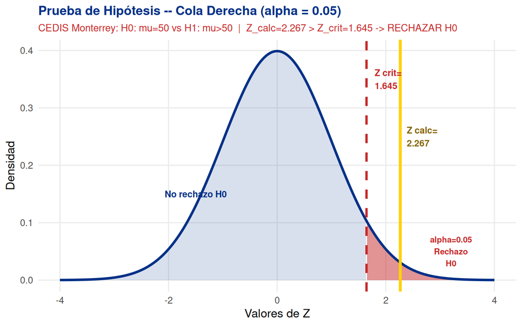

```r
# Gráfica de la distribución normal con región de rechazo
x_vals <- seq(-4, 4, length.out=400)
y_vals <- dnorm(x_vals)

df_norm <- data.frame(x=x_vals, y=y_vals)
Z_c <- qnorm(0.95)
Z_ca <- (53.4 - 50) / (9/sqrt(36))

ggplot(df_norm, aes(x, y)) +
  # Área de rechazo (cola derecha, rojo)
  geom_area(data=subset(df_norm, x >= Z_c),
            aes(x, y), fill="#C62828", alpha=0.5) +
  # Área de no rechazo (azul claro)
  geom_area(data=subset(df_norm, x < Z_c),
            aes(x, y), fill="#003087", alpha=0.15) +
  geom_line(color="#003087", size=1.3) +
  # Línea Z crítico
  geom_vline(xintercept=Z_c, color="#C62828",
             linetype="dashed", size=1.2) +
  # Línea Z calculado
  geom_vline(xintercept=Z_ca, color="#FFD100",
             linetype="solid", size=1.5) +
  annotate("text", x=Z_c+0.15, y=0.35,
           label=paste0("Z crit=\n",round(Z_c,3)),
           color="#C62828", size=3.5, hjust=0, fontface="bold") +
  annotate("text", x=Z_ca+0.12, y=0.25,
           label=paste0("Z calc=\n",round(Z_ca,3)),
           color="#856400", size=3.5, hjust=0, fontface="bold") +
  annotate("text", x=3.2, y=0.05,
           label=paste0("alpha=0.05\nRechazo\nH0"),
           color="#C62828", size=3.2, fontface="bold") +
  annotate("text", x=-1.5, y=0.15,
           label="No rechazo H0",
           color="#003087", size=3.5, fontface="bold") +
  labs(title="Prueba de Hipótesis -- Cola Derecha (alpha = 0.05)",
       subtitle="CEDIS Monterrey: H0: mu=50 vs H1: mu>50  |  Z_calc=2.267 > Z_crit=1.645 -> RECHAZAR H0",
       x="Valores de Z", y="Densidad") +
  theme_minimal(base_size=13) +
  theme(
    plot.title    = element_text(color="#003087", face="bold", size=14),
    plot.subtitle = element_text(color="#C62828", size=11),
    panel.grid.minor = element_blank()
  )
```

## Código en Python — Positron

**Instrucciones Positron:** Abre Positron IDE → New File → Python Script → pega el código → Run (▶) o Ctrl+Shift+P → “Run File”

El siguiente bloque es el **script .py equivalente** — mismos datos, mismo resultado:

```r
# ============================================================
# PRUEBA DE HIPÓTESIS PARA LA MEDIA — PYTHON
# EJEMPLO: CEDIS Monterrey — tiempo de entrega
# Positron: New Python Script → Run (▶)
# ============================================================

import math                          # para sqrt y operaciones matemáticas
import scipy.stats as stats          # para valores Z y p-values
import matplotlib.pyplot as plt      # para la gráfica
import numpy as np                   # para arrays numéricos

# --- DATOS DEL PROBLEMA ---
n     = 36       # tamaño de muestra
xbar  = 53.4     # media muestral (minutos)
s     = 9        # desviación estándar muestral
mu0   = 50       # media bajo H0 (valor a contrastar)
alpha = 0.05     # nivel de significancia

# --- PASO 1: HIPÓTESIS ---
print("="*55)
print("PRUEBA DE HIPÓTESIS — CEDIS MONTERREY")
print("="*55)
print("\nPASO 1 — Hipótesis")
print(f"  H0: mu = {mu0} min")
print(f"  H1: mu > {mu0} min  (cola derecha)")

# --- PASO 2: ESTADÍSTICO DE PRUEBA ---
# Fórmula: Z = (xbar - mu0) / (s / sqrt(n))
SE     = s / math.sqrt(n)       # error estándar de la media
Z_calc = (xbar - mu0) / SE      # estadístico Z calculado

print(f"\nPASO 2 — Estadístico de prueba")
print(f"  Error estándar  SE = {s} / sqrt({n}) = {SE:.4f}")
print(f"  Z_calculado = ({xbar} - {mu0}) / {SE:.4f} = {Z_calc:.4f}")

# --- PASO 3: VALOR CRÍTICO ---
# stats.norm.ppf(1 - alpha) devuelve el Z crítico para cola derecha
Z_crit = stats.norm.ppf(1 - alpha)   # Z crítico para α=0.05

print(f"\nPASO 3 — Valor crítico")
print(f"  Z_critico (alpha={alpha}, cola derecha) = {Z_crit:.4f}")
print(f"  Región de rechazo: Z > {Z_crit:.4f}")

# --- PASO 4: p-VALUE ---
# Cola derecha: p-value = P(Z > Z_calc) = 1 - CDF(Z_calc)
p_value = 1 - stats.norm.cdf(Z_calc)   # área a la derecha

print(f"\nPASO 4 — p-value")
print(f"  p-value = P(Z > {Z_calc:.4f}) = {p_value:.5f}")

# --- PASO 5: DECISIÓN ---
print(f"\nPASO 5 — Decisión")
print(f"  Z_calc = {Z_calc:.4f}  vs  Z_crit = {Z_crit:.4f}")
print(f"  p-value = {p_value:.5f}  vs  alpha = {alpha}")

if Z_calc > Z_crit:                      # condición de rechazo
    print(f"\n  >>> RECHAZAR H0 <<<")
    print(f"  Con alpha={alpha}, hay evidencia para afirmar")
    print(f"  que el tiempo promedio EXCEDE los {mu0} minutos.")
else:
    print(f"\n  >>> NO RECHAZAR H0 <<<")
    print(f"  Sin evidencia suficiente al {alpha*100}%.")

# --- GRÁFICA ---
x = np.linspace(-4, 4, 400)             # rango del eje X
y = stats.norm.pdf(x)                    # densidad normal estándar

fig, ax = plt.subplots(figsize=(9, 5))

# Zona de no rechazo (azul)
ax.fill_between(x, y, where=(x < Z_crit),
                color='#003087', alpha=0.15, label='No rechazar H0')

# Zona de rechazo (rojo)
ax.fill_between(x, y, where=(x >= Z_crit),
                color='#C62828', alpha=0.5, label=f'Rechazo H0 (α={alpha})')

ax.plot(x, y, color='#003087', linewidth=2)    # curva normal

# Líneas verticales
ax.axvline(Z_crit, color='#C62828', linestyle='--',
           linewidth=2, label=f'Z crítico = {Z_crit:.3f}')
ax.axvline(Z_calc, color='#856400', linestyle='-',
           linewidth=2.5, label=f'Z calculado = {Z_calc:.3f}')

ax.set_title('Prueba de Hipótesis — Cola Derecha (α=0.05)\n'
             'CEDIS Monterrey: H0: μ=50 vs H1: μ>50',
             color='#003087', fontsize=12, fontweight='bold')
ax.set_xlabel('Valores de Z', fontsize=11)
ax.set_ylabel('Densidad', fontsize=11)
ax.legend(loc='upper left', fontsize=9)
plt.tight_layout()
plt.savefig('prueba_hipotesis_ejemplo.png', dpi=150, bbox_inches='tight')
plt.show()
print("\nGráfica guardada como 'prueba_hipotesis_ejemplo.png'")
```

# Ejercicios de tu Actividad

> Lee cada problema, identifica los datos, luego adapta el código del ejemplo anterior cambiando solo la sección de datos.

## Ejercicio 1 — CEDIS Irapuato: Tiempo de Picking

**Contexto real:** El gerente de operaciones del CEDIS de una empresa distribuidora en Irapuato, Guanajuato, tiene como estándar corporativo que el tiempo promedio de picking (preparación de pedidos) es de **8.5 minutos por línea**. Tras una auditoría interna, se tomó una muestra aleatoria de **45 líneas de pedido** y se obtuvo una **media muestral de 9.2 minutos** con una **desviación estándar de 1.8 minutos**. El gerente sospecha que el proceso está tardando más de lo establecido, lo que genera retrasos en los embarques.

**Datos:**

| Parámetro | Valor |
| --- | --- |
| Tamaño de muestra (n) | 45 |
| Media muestral (x̄) | 9.2 min |
| Desviación estándar (s) | 1.8 min |
| Media bajo H₀ (μ₀) | 8.5 min |
| Nivel de significancia (α) | 5% (0.05) |
| Tipo de prueba | Cola derecha (H₁: μ > 8.5) |

**Planteamiento:**

$$H_0: \mu = 8.5 \text{ min} \qquad H_1:
\mu > 8.5 \text{ min}$$

### Solución en R

```r
# ============================================================
# EJERCICIO 1 -- CEDIS Irapuato: Tiempo de Picking
# Prueba de hipótesis para UNA MEDIA -- cola derecha
# H0: mu = 8.5 min  vs  H1: mu > 8.5 min
# ============================================================

# >>> DATOS DEL PROBLEMA -- CAMBIA ESTOS VALORES EN TU EJERCICIO <<<
n     <- 45      # tamaño de muestra (líneas de pedido auditadas)
xbar  <- 9.2     # media muestral (minutos por línea)
s     <- 1.8     # desviación estándar muestral
mu0   <- 8.5     # estándar corporativo (hipótesis nula)
alpha <- 0.05    # nivel de significancia 5%

# --- PASO 1: HIPÓTESIS ---
# H0: el tiempo promedio ES el estándar (8.5 min) -- no hay problema
# H1: el tiempo promedio SUPERA el estándar -- hay retraso
cat("PASO 1 -- Hipótesis\n")
```

```
PASO 1 -- Hipótesis
```

```r
cat("  H0: mu =", mu0, "min  (cumple el estándar)\n")
```

```
  H0: mu = 8.5 min  (cumple el estándar)
```

```r
cat("  H1: mu >", mu0, "min  (excede el estándar -> cola derecha)\n\n")
```

```
  H1: mu > 8.5 min  (excede el estándar -> cola derecha)
```

```r
# --- PASO 2: ESTADÍSTICO Z ---
SE     <- s / sqrt(n)          # error estándar = s / raíz(n)
Z_calc <- (xbar - mu0) / SE   # Z calculado con la fórmula

cat("PASO 2 -- Cálculo del estadístico\n")
```

```
PASO 2 -- Cálculo del estadístico
```

```r
cat("  SE = s/sqrt(n) =", s, "/sqrt(", n, ") =", round(SE,4), "\n")
```

```
  SE = s/sqrt(n) = 1.8 /sqrt( 45 ) = 0.2683
```

```r
cat("  Z_calc = (xbar - mu0)/SE = (",xbar,"-",mu0,") /",round(SE,4),
    "=", round(Z_calc,4), "\n\n")
```

```
  Z_calc = (xbar - mu0)/SE = ( 9.2 - 8.5 ) / 0.2683 = 2.6087
```

```r
# --- PASO 3: VALOR CRÍTICO ---
Z_crit <- qnorm(1 - alpha)     # valor Z para cola derecha con alpha=0.05
p_val  <- 1 - pnorm(Z_calc)   # p-value: área a la derecha de Z_calc

cat("PASO 3 -- Valor crítico y p-value\n")
```

```
PASO 3 -- Valor crítico y p-value
```

```r
cat("  Z_crítico =", round(Z_crit,4), "(para alpha=", alpha, ", cola derecha)\n")
```

```
  Z_crítico = 1.6449 (para alpha= 0.05 , cola derecha)
```

```r
cat("  p-value =", round(p_val,5), "\n\n")
```

```
  p-value = 0.00454
```

```r
# --- PASO 4: DECISIÓN ---
cat("PASO 4 -- Decisión\n")
```

```
PASO 4 -- Decisión
```

```r
cat("  Z_calc =", round(Z_calc,4), " | Z_crit =", round(Z_crit,4), "\n")
```

```
  Z_calc = 2.6087  | Z_crit = 1.6449
```

```r
cat("  p-value =", round(p_val,5), " | alpha =", alpha, "\n\n")
```

```
  p-value = 0.00454  | alpha = 0.05
```

```r
if (Z_calc > Z_crit) {
  cat("  *** RECHAZAR H0 ***\n\n")
  cat("  CONCLUSIÓN: Con un nivel de significancia del 5%, existe\n")
  cat("  evidencia estadística suficiente para afirmar que el tiempo\n")
  cat("  promedio de picking en el CEDIS Irapuato EXCEDE el estándar\n")
  cat("  de 8.5 min/línea. Se recomienda revisar el proceso de\n")
  cat("  preparación de pedidos e implementar mejoras.\n")
} else {
  cat("  No rechazar H0 -- sin evidencia suficiente.\n")
}
```

```
  *** RECHAZAR H0 ***

  CONCLUSIÓN: Con un nivel de significancia del 5%, existe
  evidencia estadística suficiente para afirmar que el tiempo
  promedio de picking en el CEDIS Irapuato EXCEDE el estándar
  de 8.5 min/línea. Se recomienda revisar el proceso de
  preparación de pedidos e implementar mejoras.
```

### Gráfica Ejercicio 1

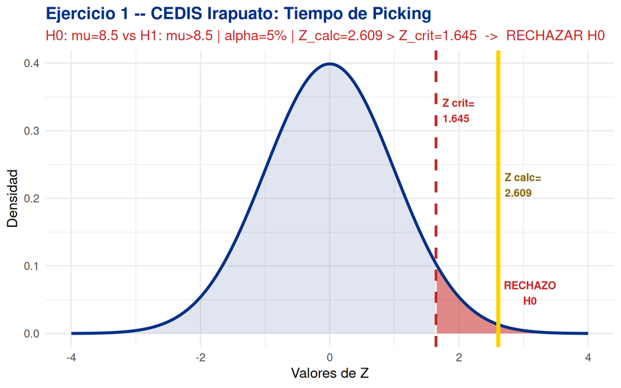

```r
x_v <- seq(-4, 4, length.out=400)
df_n <- data.frame(x=x_v, y=dnorm(x_v))
Zc1 <- qnorm(0.95)
Za1 <- (9.2-8.5)/(1.8/sqrt(45))

ggplot(df_n, aes(x,y)) +
  geom_area(data=subset(df_n,x>=Zc1), aes(x,y),
            fill="#C62828", alpha=0.55) +
  geom_area(data=subset(df_n,x<Zc1), aes(x,y),
            fill="#003087", alpha=0.12) +
  geom_line(color="#003087", size=1.3) +
  geom_vline(xintercept=Zc1, color="#C62828",
             linetype="dashed", size=1.2) +
  geom_vline(xintercept=Za1, color="#FFD100",
             linetype="solid", size=1.8) +
  annotate("text",x=Zc1+0.1,y=0.33,
           label=paste0("Z crit=\n",round(Zc1,3)),
           color="#C62828",size=3.5,hjust=0,fontface="bold") +
  annotate("text",x=Za1+0.1,y=0.22,
           label=paste0("Z calc=\n",round(Za1,3)),
           color="#856400",size=3.5,hjust=0,fontface="bold") +
  annotate("text",x=3.1,y=0.06,
           label="RECHAZO\nH0",color="#C62828",size=3.5,fontface="bold") +
  labs(title="Ejercicio 1 -- CEDIS Irapuato: Tiempo de Picking",
       subtitle=paste0("H0: mu=8.5 vs H1: mu>8.5 | alpha=5% | Z_calc=",
                       round(Za1,3)," > Z_crit=",round(Zc1,3),
                       "  ->  RECHAZAR H0"),
       x="Valores de Z", y="Densidad") +
  theme_minimal(base_size=13)+
  theme(plot.title=element_text(color="#003087",face="bold"),
        plot.subtitle=element_text(color="#C62828"))
```

### Solución en Python (Positron)

```r
# ============================================================
# EJERCICIO 1 — CEDIS Irapuato: Tiempo de Picking
# Python script para Positron
# ============================================================

import math
import scipy.stats as stats

# >>> DATOS DEL PROBLEMA <<<
n     = 45      # tamaño de muestra
xbar  = 9.2     # media muestral (min/línea)
s     = 1.8     # desviación estándar muestral
mu0   = 8.5     # estándar corporativo (H0)
alpha = 0.05    # nivel de significancia 5%

# H0: mu = 8.5   H1: mu > 8.5  (cola derecha)
SE     = s / math.sqrt(n)       # error estándar
Z_calc = (xbar - mu0) / SE      # estadístico Z

Z_crit = stats.norm.ppf(1 - alpha)      # valor crítico cola derecha
p_val  = 1 - stats.norm.cdf(Z_calc)    # p-value cola derecha

print("="*50)
print("EJERCICIO 1 — CEDIS Irapuato: Picking")
print("="*50)
print(f"  H0: mu = {mu0}  |  H1: mu > {mu0} (cola derecha)")
print(f"  SE        = {SE:.4f}")
print(f"  Z_calc    = {Z_calc:.4f}")
print(f"  Z_critico = {Z_crit:.4f}  (alpha={alpha})")
print(f"  p-value   = {p_val:.5f}")
print()

if Z_calc > Z_crit:
    print("  >>> RECHAZAR H0 <<<")
    print("  Evidencia de que el picking tarda más de 8.5 min.")
    print("  Se recomienda revisar el proceso en el CEDIS.")
else:
    print("  >>> NO RECHAZAR H0 <<<")
    print("  Sin evidencia suficiente al 5%.")
```

## Ejercicio 2 — Planta León: Control de Peso de Cajas

**Contexto real:** Una planta automotriz en León, Guanajuato, empaca refacciones en cajas con un **peso nominal de 25 kg**. El departamento de calidad toma una muestra de **60 cajas** del turno nocturno y obtiene un **peso promedio de 24.3 kg** con una **desviación estándar de 2.1 kg**. La norma de calidad exige que el peso promedio sea exactamente 25 kg (ni más ni menos, pues excederse también genera costos de flete). Con α = 10%, ¿hay evidencia de que el proceso está fuera de especificación?

**Datos:**

| Parámetro | Valor |
| --- | --- |
| n | 60 |
| x̄ | 24.3 kg |
| s | 2.1 kg |
| μ₀ | 25 kg |
| α | 10% (0.10) |
| Tipo de prueba | **Dos colas** (H₁: μ ≠ 25) |

$$H_0: \mu = 25 \text{ kg} \qquad H_1: \mu
\neq 25 \text{ kg (dos colas)}$$

### Solución en R

```r
# ============================================================
# EJERCICIO 2 -- Planta León: Control de Peso
# Prueba de hipótesis para UNA MEDIA -- DOS COLAS
# H0: mu = 25 kg  vs  H1: mu != 25 kg
# ============================================================

# >>> DATOS DEL PROBLEMA <<<
n     <- 60      # cajas muestreadas
xbar  <- 24.3    # peso promedio muestral (kg)
s     <- 2.1     # desviación estándar muestral
mu0   <- 25      # peso nominal especificado (H0)
alpha <- 0.10    # nivel de significancia 10%

cat("PASO 1 -- Hipótesis\n")
```

```
PASO 1 -- Hipótesis
```

```r
cat("  H0: mu =", mu0, "kg  (proceso bajo control)\n")
```

```
  H0: mu = 25 kg  (proceso bajo control)
```

```r
cat("  H1: mu !=", mu0, "kg  (proceso fuera de especificación -> DOS COLAS)\n\n")
```

```
  H1: mu != 25 kg  (proceso fuera de especificación -> DOS COLAS)
```

```r
# PASO 2: ESTADÍSTICO
SE     <- s / sqrt(n)
Z_calc <- (xbar - mu0) / SE

cat("PASO 2 -- Estadístico\n")
```

```
PASO 2 -- Estadístico
```

```r
cat("  SE =", round(SE,4), "\n")
```

```
  SE = 0.2711
```

```r
cat("  Z_calc =", round(Z_calc,4), "\n\n")
```

```
  Z_calc = -2.582
```

```r
# PASO 3: VALOR CRÍTICO DOS COLAS
# Para dos colas: dividir alpha entre 2 -> qnorm(1 - alpha/2)
Z_crit <- qnorm(1 - alpha/2)   # valor crítico para dos colas

# p-value dos colas = 2 * P(Z < Z_calc) ya que Z_calc es negativo
p_val  <- 2 * pnorm(Z_calc)    # dos colas (multiplicar por 2)

cat("PASO 3 -- Valor crítico (dos colas)\n")
```

```
PASO 3 -- Valor crítico (dos colas)
```

```r
cat("  Z_crítico = ±", round(Z_crit,4), "(para alpha/2 =", alpha/2, ")\n")
```

```
  Z_crítico = ± 1.6449 (para alpha/2 = 0.05 )
```

```r
cat("  Región de rechazo: Z <", -round(Z_crit,4), "o Z >", round(Z_crit,4), "\n")
```

```
  Región de rechazo: Z < -1.6449 o Z > 1.6449
```

```r
cat("  p-value =", round(p_val,5), "\n\n")
```

```
  p-value = 0.00982
```

```r
cat("PASO 4 -- Decisión\n")
```

```
PASO 4 -- Decisión
```

```r
cat("  |Z_calc| =", round(abs(Z_calc),4), " vs Z_crit =", round(Z_crit,4), "\n\n")
```

```
  |Z_calc| = 2.582  vs Z_crit = 1.6449
```

```r
if (abs(Z_calc) > Z_crit) {
  cat("  *** RECHAZAR H0 ***\n\n")
  cat("  CONCLUSIÓN: Con alpha=10%, hay evidencia estadística de que el\n")
  cat("  peso promedio de las cajas en Planta León es DIFERENTE de\n")
  cat("  25 kg. El proceso está fuera de especificación. Se recomienda\n")
  cat("  calibrar la línea de empaque inmediatamente.\n")
} else {
  cat("  No rechazar H0.\n")
}
```

```
  *** RECHAZAR H0 ***

  CONCLUSIÓN: Con alpha=10%, hay evidencia estadística de que el
  peso promedio de las cajas en Planta León es DIFERENTE de
  25 kg. El proceso está fuera de especificación. Se recomienda
  calibrar la línea de empaque inmediatamente.
```

### Gráfica Ejercicio 2

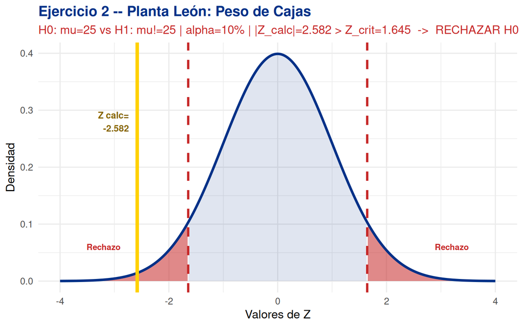

```r
x_v2 <- seq(-4,4,length.out=400)
df_n2 <- data.frame(x=x_v2, y=dnorm(x_v2))
Zc2 <- qnorm(0.95)
Za2 <- (24.3-25)/(2.1/sqrt(60))

ggplot(df_n2, aes(x,y)) +
  geom_area(data=subset(df_n2,x<=-Zc2), aes(x,y),
            fill="#C62828",alpha=0.55) +
  geom_area(data=subset(df_n2,x>=Zc2),  aes(x,y),
            fill="#C62828",alpha=0.55) +
  geom_area(data=subset(df_n2,x>-Zc2 & x<Zc2), aes(x,y),
            fill="#003087",alpha=0.12) +
  geom_line(color="#003087",size=1.3) +
  geom_vline(xintercept=c(-Zc2,Zc2),color="#C62828",
             linetype="dashed",size=1.2) +
  geom_vline(xintercept=Za2,color="#FFD100",
             linetype="solid",size=1.8) +
  annotate("text",x=Za2-0.15,y=0.28,
           label=paste0("Z calc=\n",round(Za2,3)),
           color="#856400",size=3.5,hjust=1,fontface="bold") +
  annotate("text",x=-3.2,y=0.06,
           label="Rechazo",color="#C62828",size=3.2,fontface="bold") +
  annotate("text",x=3.2,y=0.06,
           label="Rechazo",color="#C62828",size=3.2,fontface="bold") +
  labs(title="Ejercicio 2 -- Planta León: Peso de Cajas",
       subtitle=paste0("H0: mu=25 vs H1: mu!=25 | alpha=10% | |Z_calc|=",
                       round(abs(Za2),3)," > Z_crit=",round(Zc2,3),
                       "  ->  RECHAZAR H0"),
       x="Valores de Z",y="Densidad") +
  theme_minimal(base_size=13)+
  theme(plot.title=element_text(color="#003087",face="bold"),
        plot.subtitle=element_text(color="#C62828"))
```

### Solución en Python (Positron)

```r
# ============================================================
# EJERCICIO 2 — Planta León: Control de Peso
# Python script para Positron — DOS COLAS
# ============================================================

import math
import scipy.stats as stats

# >>> DATOS <<<
n     = 60       # cajas muestreadas
xbar  = 24.3     # peso promedio muestral
s     = 2.1      # desviación estándar
mu0   = 25       # peso nominal (H0)
alpha = 0.10     # nivel de significancia 10%

# H0: mu = 25   H1: mu ≠ 25  (dos colas)
SE     = s / math.sqrt(n)
Z_calc = (xbar - mu0) / SE

# Para dos colas: Z_crit = Z(alpha/2)
Z_crit = stats.norm.ppf(1 - alpha/2)    # valor crítico (positivo)

# p-value dos colas: 2 * P(Z <= Z_calc) para Z_calc negativo
p_val  = 2 * stats.norm.cdf(Z_calc)    # multiplicar por 2 (simetría)

print("="*50)
print("EJERCICIO 2 — Planta León: Peso de Cajas")
print("="*50)
print(f"  H0: mu = {mu0}  |  H1: mu ≠ {mu0} (dos colas)")
print(f"  SE        = {SE:.4f}")
print(f"  Z_calc    = {Z_calc:.4f}")
print(f"  Z_critico = ±{Z_crit:.4f}  (alpha/2={alpha/2})")
print(f"  p-value   = {p_val:.5f}")
print()

if abs(Z_calc) > Z_crit:    # para dos colas se compara |Z_calc| vs Z_crit
    print("  >>> RECHAZAR H0 <<<")
    print("  El peso promedio es diferente de 25 kg.")
    print("  El proceso está fuera de especificación.")
else:
    print("  >>> NO RECHAZAR H0 <<<")
    print("  Sin evidencia suficiente al 10%.")
```

## Ejercicio 3 — Rutas de Distribución: GPS vs Sin GPS

**Contexto real:** Una empresa de transporte de carga en el Bajío opera rutas de distribución desde su planta en Celaya hasta clientes en la región. El departamento de logística implementó un sistema GPS con optimización de rutas para un grupo de choferes. Para evaluar su impacto, se registró el tiempo de entrega (minutos) en dos grupos independientes: **35 choferes sin GPS** (tiempo promedio 42 min, varianza 16 min²) y **38 choferes con GPS** (tiempo promedio 38 min, varianza 9 min²). Con α = 1%, ¿hay evidencia de que los choferes sin GPS tardan significativamente más?

**Datos:**

|  | Sin GPS (Grupo 1) | Con GPS (Grupo 2) |
| --- | --- | --- |
| n | 35 | 38 |
| x̄ | 42 min | 38 min |
| s² (varianza) | 16 min² | 9 min² |

$$H_0: \mu_1 = \mu_2 \qquad H_1: \mu_1
> \mu_2 \text{ (sin GPS tarda MÁS → cola derecha)}$$

### Solución en R

```r
# ============================================================
# EJERCICIO 3 -- Rutas de distribución: GPS vs Sin GPS
# Prueba para DOS MEDIAS INDEPENDIENTES -- cola derecha
# H0: mu1 = mu2  vs  H1: mu1 > mu2
# ============================================================

# >>> DATOS GRUPO 1: Sin GPS <<<
n1   <- 35    # choferes sin GPS
xbar1 <- 42   # tiempo promedio (min)
var1  <- 16   # varianza muestral (min²)  -- s1² = 16

# >>> DATOS GRUPO 2: Con GPS <<<
n2   <- 38    # choferes con GPS
xbar2 <- 38   # tiempo promedio (min)
var2  <- 9    # varianza muestral (min²)  -- s2² = 9

alpha <- 0.01  # nivel de significancia 1%

cat("PASO 1 -- Hipótesis\n")
```

```
PASO 1 -- Hipótesis
```

```r
cat("  H0: mu1 = mu2  (mismo tiempo con y sin GPS)\n")
```

```
  H0: mu1 = mu2  (mismo tiempo con y sin GPS)
```

```r
cat("  H1: mu1 > mu2  (sin GPS tarda MÁS -> cola derecha)\n\n")
```

```
  H1: mu1 > mu2  (sin GPS tarda MÁS -> cola derecha)
```

```r
# PASO 2: ESTADÍSTICO PARA DOS MEDIAS INDEPENDIENTES
# Fórmula: Z = (xbar1 - xbar2 - 0) / sqrt(var1/n1 + var2/n2)
# Donde var1 y var2 son las VARIANZAS muestrales (s1² y s2²)
SE_2m  <- sqrt(var1/n1 + var2/n2)          # error estándar de la diferencia
Z_calc3 <- (xbar1 - xbar2) / SE_2m         # estadístico Z

cat("PASO 2 -- Estadístico de prueba\n")
```

```
PASO 2 -- Estadístico de prueba
```

```r
cat("  SE = sqrt(var1/n1 + var2/n2)\n")
```

```
  SE = sqrt(var1/n1 + var2/n2)
```

```r
cat("     = sqrt(", var1, "/", n1, "+", var2, "/", n2, ")\n")
```

```
     = sqrt( 16 / 35 + 9 / 38 )
```

```r
cat("     =", round(SE_2m,4), "\n")
```

```
     = 0.8331
```

```r
cat("  Z_calc = (", xbar1, "-", xbar2, ") /", round(SE_2m,4),
    "=", round(Z_calc3,4), "\n\n")
```

```
  Z_calc = ( 42 - 38 ) / 0.8331 = 4.8016
```

```r
# PASO 3: VALOR CRÍTICO cola derecha alpha=0.01
Z_crit3 <- qnorm(1 - alpha)        # Z para cola derecha alpha=1%
p_val3  <- 1 - pnorm(Z_calc3)     # p-value cola derecha

cat("PASO 3 -- Valor crítico\n")
```

```
PASO 3 -- Valor crítico
```

```r
cat("  Z_crítico =", round(Z_crit3,4),
    "(alpha =", alpha, ", cola derecha)\n")
```

```
  Z_crítico = 2.3263 (alpha = 0.01 , cola derecha)
```

```r
cat("  p-value =", round(p_val3,6), "\n\n")
```

```
  p-value = 1e-06
```

```r
cat("PASO 4 -- Decisión\n")
```

```
PASO 4 -- Decisión
```

```r
cat("  Z_calc =", round(Z_calc3,4), " vs Z_crit =", round(Z_crit3,4), "\n\n")
```

```
  Z_calc = 4.8016  vs Z_crit = 2.3263
```

```r
if (Z_calc3 > Z_crit3) {
  cat("  *** RECHAZAR H0 ***\n\n")
  cat("  CONCLUSIÓN: Con alpha=1%, existe evidencia estadística muy\n")
  cat("  fuerte para afirmar que los choferes SIN GPS tardan\n")
  cat("  significativamente MÁS que los choferes CON GPS.\n")
  cat("  Se recomienda implementar el sistema GPS en toda la flota\n")
  cat("  para reducir los tiempos de entrega y costos operativos.\n")
} else {
  cat("  No rechazar H0.\n")
}
```

```
  *** RECHAZAR H0 ***

  CONCLUSIÓN: Con alpha=1%, existe evidencia estadística muy
  fuerte para afirmar que los choferes SIN GPS tardan
  significativamente MÁS que los choferes CON GPS.
  Se recomienda implementar el sistema GPS en toda la flota
  para reducir los tiempos de entrega y costos operativos.
```

### Gráfica Ejercicio 3

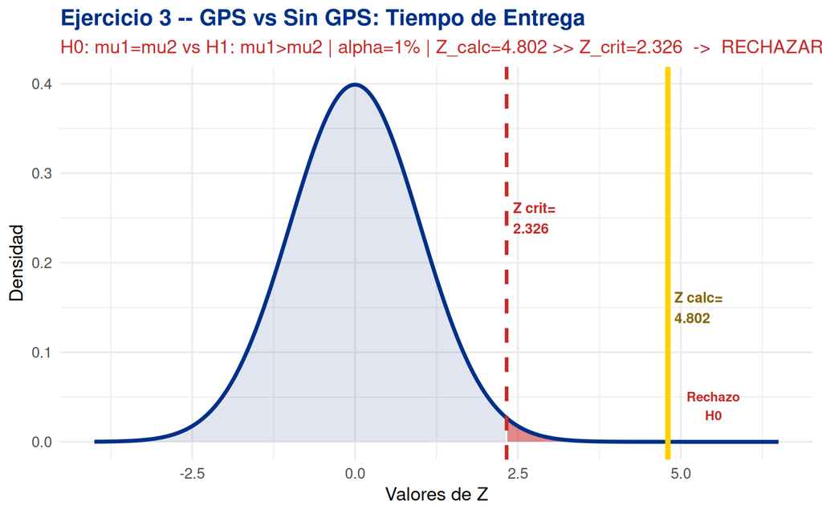

```r
x_v3 <- seq(-4,6.5,length.out=500)
df_n3 <- data.frame(x=x_v3, y=dnorm(x_v3))
Zc3 <- qnorm(0.99)
Za3 <- (42-38)/sqrt(16/35+9/38)

ggplot(df_n3, aes(x,y)) +
  geom_area(data=subset(df_n3,x>=Zc3), aes(x,y),
            fill="#C62828",alpha=0.55) +
  geom_area(data=subset(df_n3,x<Zc3), aes(x,y),
            fill="#003087",alpha=0.12) +
  geom_line(color="#003087",size=1.3) +
  geom_vline(xintercept=Zc3,color="#C62828",
             linetype="dashed",size=1.2) +
  geom_vline(xintercept=Za3,color="#FFD100",
             linetype="solid",size=1.8) +
  annotate("text",x=Zc3+0.1,y=0.25,
           label=paste0("Z crit=\n",round(Zc3,3)),
           color="#C62828",size=3.5,hjust=0,fontface="bold") +
  annotate("text",x=Za3+0.1,y=0.15,
           label=paste0("Z calc=\n",round(Za3,3)),
           color="#856400",size=3.5,hjust=0,fontface="bold") +
  annotate("text",x=5.5,y=0.04,
           label="Rechazo\nH0",color="#C62828",size=3.2,fontface="bold") +
  labs(title="Ejercicio 3 -- GPS vs Sin GPS: Tiempo de Entrega",
       subtitle=paste0("H0: mu1=mu2 vs H1: mu1>mu2 | alpha=1% | Z_calc=",
                       round(Za3,3)," >> Z_crit=",round(Zc3,3),
                       "  ->  RECHAZAR H0 contundentemente"),
       x="Valores de Z",y="Densidad") +
  theme_minimal(base_size=13)+
  theme(plot.title=element_text(color="#003087",face="bold"),
        plot.subtitle=element_text(color="#C62828"))
```

### Solución en Python (Positron)

```r
# ============================================================
# EJERCICIO 3 — Rutas de distribución: GPS vs Sin GPS
# Python script para Positron — DOS MEDIAS INDEPENDIENTES
# ============================================================

import math
import scipy.stats as stats

# >>> DATOS GRUPO 1: Sin GPS <<<
n1    = 35      # choferes sin GPS
xbar1 = 42      # tiempo promedio (min)
var1  = 16      # varianza muestral (s1²)

# >>> DATOS GRUPO 2: Con GPS <<<
n2    = 38      # choferes con GPS
xbar2 = 38      # tiempo promedio (min)
var2  = 9       # varianza muestral (s2²)

alpha = 0.01    # nivel de significancia 1%

# H0: mu1 = mu2  |  H1: mu1 > mu2  (cola derecha)
# Fórmula del error estándar para dos medias independientes
SE_2m  = math.sqrt(var1/n1 + var2/n2)       # error estándar
Z_calc = (xbar1 - xbar2) / SE_2m            # estadístico Z

Z_crit = stats.norm.ppf(1 - alpha)          # Z crítico cola derecha
p_val  = 1 - stats.norm.cdf(Z_calc)        # p-value cola derecha

print("="*55)
print("EJERCICIO 3 — Rutas de distribución: GPS vs Sin GPS")
print("="*55)
print(f"  H0: mu1 = mu2  |  H1: mu1 > mu2 (cola derecha)")
print(f"  SE = sqrt({var1}/{n1} + {var2}/{n2}) = {SE_2m:.4f}")
print(f"  Z_calc    = ({xbar1} - {xbar2}) / {SE_2m:.4f} = {Z_calc:.4f}")
print(f"  Z_critico = {Z_crit:.4f}  (alpha={alpha})")
print(f"  p-value   = {p_val:.6f}")
print()

if Z_calc > Z_crit:
    print("  >>> RECHAZAR H0 <<<")
    print("  Evidencia muy fuerte: choferes sin GPS tardan más.")
    print("  Se recomienda implementar GPS en toda la flota.")
else:
    print("  >>> NO RECHAZAR H0 <<<")
    print("  Sin evidencia suficiente al 1%.")
```

# Resumen de los Tres Ejercicios

Resumen de los tres ejercicios de la Actividad 5

| Ejercicio | H0 | H1 | alpha | Z_calc | Z_crit | Decisión |
| --- | --- | --- | --- | --- | --- | --- |
| 1 – CEDIS Irapuato | mu = 8.5 min | mu > 8.5 (->) | 5% | 2.6087 | >1.6449 | RECHAZAR H0 |
| 2 – Planta León | mu = 25 kg | mu != 25 (<->) | 10% | -2.5820 | ±1.6449 | RECHAZAR H0 |
| 3 – GPS vs Sin GPS | mu1 = mu2 | mu1 > mu2 (->) | 1% | 4.8016 | >2.3263 | RECHAZAR H0 |

# Rúbrica de Evaluación

Rúbrica de Evaluación – Actividad 5 (Total: 10 puntos)

| Criterio | Puntos | Para_obtener_max |
| --- | --- | --- |
| Preguntas teóricas (I) | 3 | Responder correctamente las 3 preguntas |
| Planteamiento de hipótesis | 1.5 | Plantear H0 y H1 correctamente en los 3 ejercicios |
| Estadístico y nivel de significancia | 1.5 | Establecer alpha, estadístico y fórmula en los 3 ejercicios |
| Regla de decisión y conclusión | 1.5 | Región de rechazo y conclusión correctas en los 3 ejercicios |
| Presentación | 1 | PDF limpio, legible, con capturas de pantalla claras |
| Entrega y asistencia a asesoría | 1.5 | Entregar en tiempo y asistir a asesoría |

**Checklist antes de entregar:**

☐ Respondí las 3 preguntas teóricas con mis propias palabras

☐ Cada ejercicio tiene H0, H1, α, Z_calc, Z_crit, región de rechazo y conclusión

☐ Incluí capturas de pantalla de la consola de R o Python

☐ El archivo está en PDF con portada (nombre, matrícula, grupo, fecha)

☐ El nombre del archivo es: APELLIDO_NOMBRE_ACTIVIDAD_5_EI.pdf

*Prof. Fausto Noé Jiménez | Estadística Inferencial | SABES Campus San Felipe | Mayo–Agosto 2026*